# Predicting 2021 CFB Games

# What is this?

This page displays predictions for games in the 2021 CFB season. These predictions come from a model built on historical college football play by play and game data in order to simulate upcoming games. All data is from collegefootballdata.com.

# 1 Week 10 Predictions

This table displays the results of simulating week 10 of the 2021 CFB season 1000 times. These simulations are run one week in advance, using information available in the lead up to week 10. For the first week of the season, team ratings are based solely on information from previous seasons.

**Quality** is the (harmonic) mean of the two team’s overall rating, with 100 indicating a game between highly rated opponents. **Pr(HomeWin)** is the percentage of times that the home team won the game across every simulation.

| Season | Week | Quality | Home | Away | Pr(HomeWin) | Prediction | Result | Correct | correct |
| --- | --- | --- | --- | --- | --- | --- | --- | --- | --- |
| 2021 | 10 | 88 | Alabama | LSU | 0.939 | Alabama by 27 |  |  |  |
| 2021 | 10 | 84 | Texas A&M | Auburn | 0.644 | Texas A&M by 6 |  |  |  |
| 2021 | 10 | 74 | Nebraska | Ohio State | 0.114 | Ohio State by 18 |  |  |  |
| 2021 | 10 | 74 | West Virginia | Oklahoma State | 0.458 | Oklahoma State by 2 |  |  |  |
| 2021 | 10 | 73 | Georgia | Missouri | 0.978 | Georgia by 34.5 |  |  |  |
| 2021 | 10 | 72 | Iowa State | Texas | 0.666 | Iowa State by 6 |  |  |  |
| 2021 | 10 | 71 | Washington | Oregon | 0.389 | Oregon by 6 |  |  |  |
| 2021 | 10 | 69 | Ole Miss | Liberty | 0.705 | Ole Miss by 9 |  |  |  |
| 2021 | 10 | 69 | Purdue | Michigan State | 0.377 | Michigan State by 6 |  |  |  |
| 2021 | 10 | 69 | Arkansas | Mississippi State | 0.593 | Arkansas by 4 |  |  |  |

[output cut: 51 more lines]

# 2 Results Through Week 9

How has the model performed so far in 2021?

## 2.1 Assessment

The model predicts the probability that the home team will win and their expected margin of victory (or defeat). I assess the model’s performance by assessing the accuracy of its predictions (win/loss), the logloss of its probabilities, and the mean absolute error of the margin.

| Season | Week | N | Outcome Accuracy | Outcome LogLoss | Margin MAE |
| --- | --- | --- | --- | --- | --- |
| 2021 | 1 | 89 | 0.75 | 0.44 | 15.2 |
| 2021 | 2 | 82 | 0.82 | 0.37 | 15.4 |
| 2021 | 3 | 73 | 0.84 | 0.45 | 13.2 |
| 2021 | 4 | 67 | 0.79 | 0.47 | 12.9 |
| 2021 | 5 | 61 | 0.62 | 0.59 | 14.8 |
| 2021 | 6 | 51 | 0.71 | 0.61 | 11.3 |
| 2021 | 7 | 52 | 0.77 | 0.58 | 13.3 |
| 2021 | 8 | 54 | 0.69 | 0.61 | 13.1 |
| 2021 | 9 | 53 | 0.72 | 0.56 | 11.9 |
| Season Average: |  |  | 0.75 | 0.50 | 13.7 |

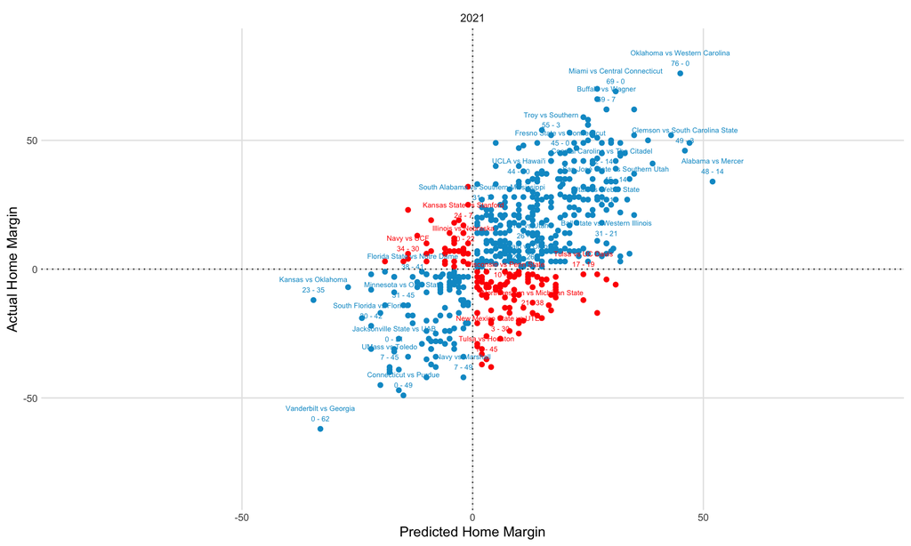

## 2.2 Results

The following table shows the results of games played in previous weeks next to the model’s predictions.

| Season | Week | Quality | Home | Away | Pr(HomeWin) | Prediction | Result | Correct | correct |
| --- | --- | --- | --- | --- | --- | --- | --- | --- | --- |
| 2021 | 9 | 95 | Florida | Georgia | 0.195 | Georgia by 16 | Georgia by 27 | Yes | 1 |
| 2021 | 9 | 88 | Ohio State | Penn State | 0.829 | Ohio State by 17 | Ohio State by 9 | Yes | 1 |
| 2021 | 9 | 80 | Michigan State | Michigan | 0.580 | Michigan State by 2 | Michigan State by 4 | Yes | 1 |
| 2021 | 9 | 78 | Auburn | Ole Miss | 0.574 | Auburn by 3 | Auburn by 11 | Yes | 1 |
| 2021 | 9 | 77 | Wisconsin | Iowa | 0.522 | Wisconsin by 1 | Wisconsin by 20 | Yes | 1 |
| 2021 | 9 | 74 | Oklahoma | Texas Tech | 0.949 | Oklahoma by 28 | Oklahoma by 31 | Yes | 1 |
| 2021 | 9 | 73 | Baylor | Texas | 0.627 | Baylor by 4 | Baylor by 7 | Yes | 1 |
| 2021 | 9 | 72 | Notre Dame | North Carolina | 0.860 | Notre Dame by 18 | Notre Dame by 10 | Yes | 1 |
| 2021 | 9 | 71 | Mississippi State | Kentucky | 0.453 | Kentucky by 2 | Mississippi State by 14 | No | 0 |
| 2021 | 9 | 70 | West Virginia | Iowa State | 0.430 | Iowa State by 3 | West Virginia by 7 | No | 0 |

[output cut: 572 more lines]

# 3 Predicting the Rest of the Season

This table displays the results of simulating the rest of the 2021 season 1000 times. These simulations are run weeks in advance, where the remainder of the season is simulated using only the information as of week 9.

For example, we simulate the entire season before any games are played by simulating week two based on the (simulated) results of week one, then simulating week three based on the (simulated) results from week two. As a result, predictions for future weeks tend to be less accurate than predictions made one week in advance and are likely to change as we get closer to the actual game.

| Season | Week | Quality | Home | Away | Pr(HomeWin) | Prediction | Result | Correct | correct |
| --- | --- | --- | --- | --- | --- | --- | --- | --- | --- |
| 2021 | 10 | 88 | Alabama | LSU | 0.939 | Alabama by 27 |  |  |  |
| 2021 | 10 | 84 | Texas A&M | Auburn | 0.644 | Texas A&M by 6 |  |  |  |
| 2021 | 10 | 74 | Nebraska | Ohio State | 0.114 | Ohio State by 18 |  |  |  |
| 2021 | 10 | 74 | West Virginia | Oklahoma State | 0.458 | Oklahoma State by 2 |  |  |  |
| 2021 | 10 | 73 | Georgia | Missouri | 0.978 | Georgia by 34.5 |  |  |  |
| 2021 | 10 | 72 | Iowa State | Texas | 0.666 | Iowa State by 6 |  |  |  |
| 2021 | 10 | 71 | Washington | Oregon | 0.389 | Oregon by 6 |  |  |  |
| 2021 | 10 | 69 | Ole Miss | Liberty | 0.705 | Ole Miss by 9 |  |  |  |
| 2021 | 10 | 69 | Purdue | Michigan State | 0.377 | Michigan State by 6 |  |  |  |
| 2021 | 10 | 69 | Arkansas | Mississippi State | 0.593 | Arkansas by 4 |  |  |  |

[output cut: 249 more lines]